# Análisis de la serie temporal

## Introducción

Una empresa tecnológica cuya área de negocio es la inteligencia artificial es contratada por una empresa eléctrica para que diseñe un sistema de recomendación que haga ofertas personalizadas a sus clientes sobre los paquetes energéticos más adecuados a sus consumos. Para ello, la empresa primero debe llevar a cabo un análisis exhaustivo de los consumos energéticos y diseñar una técnica de predicción que sea capaz de predecir dichos consumos con un horizonte temporal dado. La empresa eléctrica suministra a la empresa tecnológica para dicho cometido los consumos eléctricos desde el 01 de enero de 2015 hasta el 31 de diciembre de 2015 medidos con una frecuencia temporal de 10 minutos.

Se pide:

1. Analizar la serie temporal de consumos eléctricos y describir brevemente las principales características de esta.
2. Realizar un estudio para determinar si la serie temporal presenta *outliers*. Describir brevemente el estudio realizado y las conclusiones alcanzadas.
3. Seleccionar un artículo publicado en una revista científica de prestigio internacional en el que se presente un método de predicción. Estudiar de manera detallada el método publicado y describirlo de forma resumida.
4. Aplicar el método seleccionado en el apartado anterior para obtener una predicción del consumo eléctrico con un horizonte temporal de 4 horas para los días de la semana desde el lunes 8 de junio hasta el domingo 14 de junio. Para ello, se debe implementar un método de predicción en el lenguaje de programación que se estime oportuno o bien usar software libre disponible como WEKA, R, KEEL, … Una vez obtenidas las predicciones del periodo indicado, visualizar los resultados (predicciones, errores, …).

El trabajo de investigación se realiza utilizando el lenguaje de programación R y todos los datos y el código necesarios para reproducir el estudio se proporcionan dentro de este documento para garantizar que éste sea completamente reproducible.

Se utilizan los siguientes paquetes para el análisis:

```r
library(tidyverse)
library(lubridate)
library(xts)
library(forecast)
```

- tidyverse es un conjunto de librerías de R diseñadas para la *“Ciencia de datos”*.
- lubridate es una librería que permite manipular fechas e intervalos de tiempo.
- xts es una librería que permite convertir datos en series temporales.
- [forecast](https://www.rdocumentation.org/packages/forecast/) es una librería que contiene métodos y herramientas para analizar series temporales

## Datos de la serie temporal

Los datos están disponibles para descargar [aquí](https://github.com/lrodrin/masterAI/raw/master/A9/Series%20Temporales/Demanda_2015.csv). Una vez descargados, se cargan en el espacio de trabajo conel siguiente comando:

```r
data <- read.csv("Demanda_2015.csv", header = FALSE, sep = ",")
```

Buscamos valores perdidos.

```r
sum(is.na(data))
```

```
## [1] 0
```

Vemos que no existen valores perdidos, por lo tanto no tendremos que eliminarlos.

```r
# Establecemos nombres a las columnas
colnames(data) <- c("date", "time", "demand")
head(data, 10)
```

```
##          date time demand
## 1  01/01/2015 0:00  25459
## 2  01/01/2015 0:10  25591
## 3  01/01/2015 0:20  25531
## 4  01/01/2015 0:30  25453
## 5  01/01/2015 0:40  25329
## 6  01/01/2015 0:50  25247
## 7  01/01/2015 1:00  25093
## 8  01/01/2015 1:10  24853
## 9  01/01/2015 1:20  24678
## 10 01/01/2015 1:30  24391
```

```r
summary(data)
```

```
##      date               time               demand
##  Length:52560       Length:52560       Min.   :17985
##  Class :character   Class :character   1st Qu.:24392
##  Mode  :character   Mode  :character   Median :28566
##                                        Mean   :28349
##                                        3rd Qu.:31664
##                                        Max.   :40648
```

Tenemos la variable *date* como *character*, la variable *time* como *character* y la variable *demand* como *integer.* Para su análisis posterior, el marco de datos de fechas y horas se formatea. Para ello, primero crearemos una nueva columna *datetime*, donde juntaremos las fechas con las horas usando la función *cbind()*. Luego procederemos a la conversión de tipos *character* a *POSIXct* para la fecha-hora usando la función *parse_date_time()*.

```r
data <- cbind(datetime = paste(data$date, data$time), data)
data$datetime <- parse_date_time(data$datetime, "dmY HMS",
                                 truncated = 3, tz = "UTC")
```

Veamos los datos:

```r
head(data, 10)
```

```
##               datetime       date time demand
## 1  2015-01-01 00:00:00 01/01/2015 0:00  25459
## 2  2015-01-01 00:10:00 01/01/2015 0:10  25591
## 3  2015-01-01 00:20:00 01/01/2015 0:20  25531
## 4  2015-01-01 00:30:00 01/01/2015 0:30  25453
## 5  2015-01-01 00:40:00 01/01/2015 0:40  25329
## 6  2015-01-01 00:50:00 01/01/2015 0:50  25247
## 7  2015-01-01 01:00:00 01/01/2015 1:00  25093
## 8  2015-01-01 01:10:00 01/01/2015 1:10  24853
## 9  2015-01-01 01:20:00 01/01/2015 1:20  24678
## 10 2015-01-01 01:30:00 01/01/2015 1:30  24391
```

## Visualización de la serie temporal

La siguiente figura muestra la distribución del consumo eléctrico a lo largo del 2015.

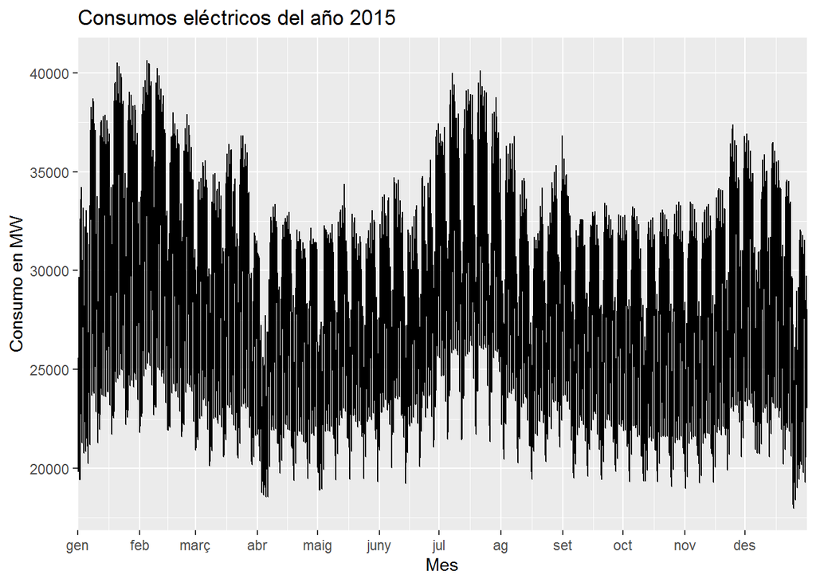

```r
ggplot(data = data, aes(x = datetime, y = demand)) +
  geom_line() +
  scale_x_datetime(date_labels = "%b",
                   breaks = "1 month",
                   expand = c(0, 0)) +
  ggtitle("Consumos eléctricos del año 2015") +
  xlab("Mes") +
  ylab("Consumo en MW")
```

Observando la figura se puede detectar una dependencia estacional en el consumo eléctrico, aunque pueden existir otros factores que pueden afectar a la serie, como los días festivos, los fines de semana, … Parece que el principal desafío introducido por la serie temporal podría ser su estacionalidad múltiple. En ese caso, las siguientes estacionalidades pueden estar presentes:

- Las personas usan la mayoría de sus electrodomésticos en determinadas horas del día, lo que resulta en una estacionalidad diaria.
- Las personas usan la electricidad de manera diferente los días entre semana y los fines de semana, lo que resulta en una estacionalidad semanal.
- Las personas usan la electricidad de manera diferente en diferentes épocas del año, lo que resulta en una estacionalidad anual.

Para mejorar la visualización de la distribución del consumo eléctrico a lo largo del 2015, la siguiente figura es muy útil.

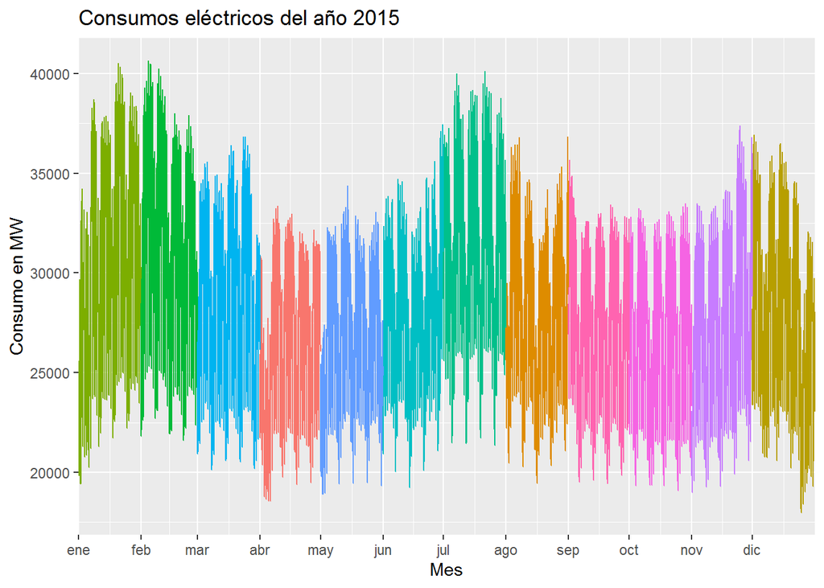

```r
ggplot(data, aes(x = datetime, y = demand)) +
  geom_line(aes(colour = month)) +
  scale_x_datetime(date_labels = "%b",
                   breaks = "1 month",
                   expand = c(0, 0)) +
  ggtitle("Consumos eléctricos del año 2015") +
  xlab("Mes") +
  ylab("Consumo en MW") +
  theme(legend.position = "none")
```

## Componentes de la serie temporal

Es frecuente analizar las series temporales des del punto de vista de sus componentes estructurales. Pero primero necesitamos que R trate los datos como una serie temporal, así que para ello tendremos que determinar apropiadamente sus características con la función *ts()*. Para definir la serie correctamente escribimos:

```r
ts <- ts(data$demand, frequency = 24 * 60 / 10)
# El argumento frequency de la función ts() se utiliza para indicar
# la periodicidad de la serie (en este caso es de 10 minutos)
```

Los componentes de una serie temporal son:

- **Tendencia**. Un aumento o disminución a largo plazo de los datos se denomina tendencia. No tiene por qué ser necesariamente lineal. Es el patrón subyacente en los datos a lo largo del tiempo.
- **Estacional** o **Periódico**. Cuando una serie está influenciada por factores estacionales. Como en este caso y hemos podido visualizar en el apartado anterior.
- **Cíclico**. Cuando los datos muestran subidas y bajadas que no son de un mismo período.

En R se pueden averiguar los componentes de la serie temporal con la función *decompose*.

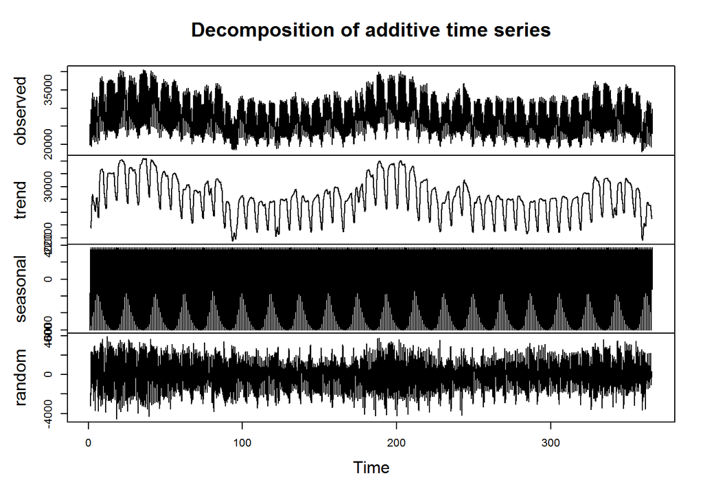

```r
componentes.ts <- decompose(ts)
plot(componentes.ts)
```

En la figura se observant cuatro sub-figuras:

- observed: los datos actuales.
- trend: el movimiento general hacia arriba o hacia abajo de los datos.
- seasonal: cualquier patrón mensual o anual de los datos.
- random: parte inexplicable de los datos.

A partir de las sub-figuras se puede determinar que la serie temporal no presenta una tendencia clara. Por ese motivo podría ser estacionaria. También se puede observar que la serie podría ser estacionaria en cuando a la varianza, ya que no se aprecia gran variabilidad. Pero presenta una estacionalidad muy marcada (el consumo aumenta durante los meses de invierno y verano). Y por ese motivo la serie **no es estacionaria**. Según que modelo sea seleccionado y para mejorar las futuras predicciones, se debe eliminar esa estacionalidad de la serie. Las series temporales no estacionarias son más difíciles de predecir.

Pero antes, para confirmar que la serie no es estacionaria trazaremos la gráfica de su función de autocorrelación, usando la función *acf()*. La función de autocorrelación *acf()* proporciona la autocorrelación en todos los retrasos posibles. La autocorrelación en el retraso 0 se incluye por defecto, lo que siempre toma el valor 1, ya que representa la correlación entre los datos y ellos mismos.

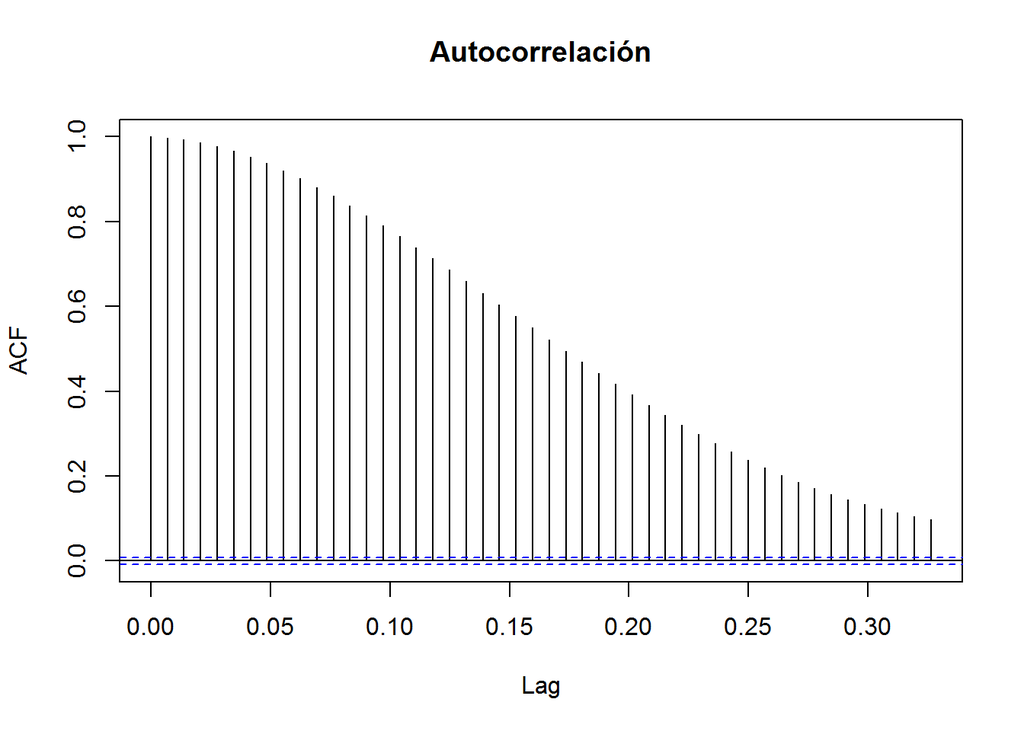

```r
acf(ts, main = "Autocorrelación")
```

# Outliers

## Identificación de outliers

En el capítulo anterior, durante un breve análisis, se ha comentado que podrían existir factores que afecten a la serie temporal. Uno de esos factores podría ser que, durante los fines de semana, el consumo eléctrico disminuya considerablemente en comparación con el resto de los días de la semana, y eso provocaría la aparición de valores atípicos en la serie. Otro factor que puede hacer variar el consumo eléctrico considerablemente y provocar la aparición de valores atípicos en la serie, son los días festivos. Así, inicialmente se consideran estos dos factores para identificar valores atípicos en la serie, si es que existen. Primero vemos si el consumo eléctrico durante los fines de semana es más bajo que entre semana. Para ello, se añade a los datos una columna nueva *day*, para indicar los días de la semana de la serie.

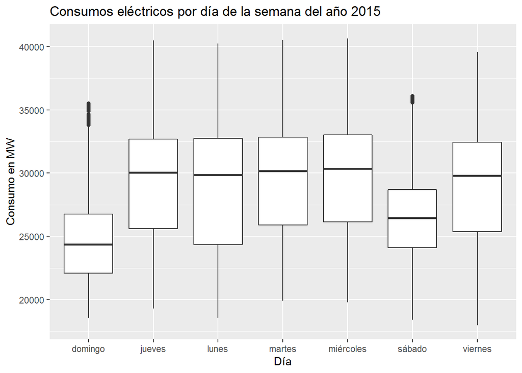

```r
data$day <- format(data$datetime, format = "%A")
ggplot(data, aes(day, demand)) +
  geom_boxplot() +
  ggtitle("Consumos eléctricos por día de la semana del año 2015") +
  xlab("Día") + ylab("Consumo en MW")
```

Como se observa en la figura anterior durante los fines de semana (sábado y domingo), la demanda disminuye considerablemente en comparación con el resto de los días de la semana y se observan valores atípicos. Por otro lado, a continuación, nos fijaremos en qué rangos se mueve la demanda del consumo eléctrico a lo largo del 2015 para identificar más valores atípicos. Se usa un histograma para que aporte esa información con un simple vistazo.

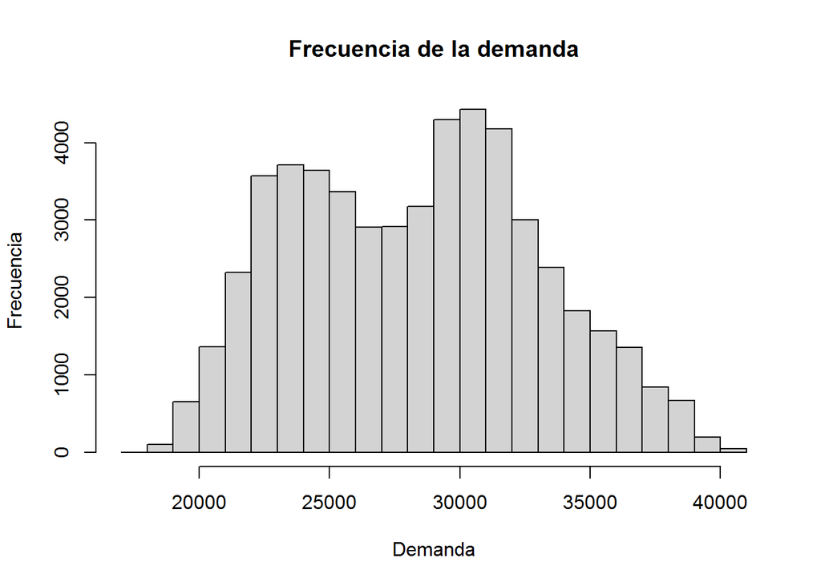

```r
hist(data$demand,
     main = "Frecuencia de la demanda",
     ylab = "Frecuencia",
     xlab = "Demanda")
```

Vemos que el histograma nos muestra una distribución extraña de la demanda.

- Hay poca frecuencia de la demanda, cuando la demanda es inferior a 22000 MW y superior a 34000 MW (aproximadamente).
- La frecuencia de la demanda es frecuente entre 22000 MW y 34000 MW.
- La baja demanda es más frecuente de lo normal dentro del conjunto de datos de la serie. Parece que predominan bastantes valores atípicos.

Se considera que es interesante estudiar cuantos valores atípicos hay en la demanda y porqué lo son. Para ello, el primer paso es convertir la variable demanda, una variable numérica, en una variable categórica. Se define la siguiente categorización, que a priori parece razonable, basándonos en el histograma:

- Hasta 22000 MW la demanda es baja (*low*).
- De 22000 a 34000 MW la demanda no se consideraría un valor atípico (*medium*).
- Mayor de 34000 MW la demanda es alta (*high*).

```r
breakPoints <- c(0, 22000, 34000, Inf)
categories <- c("low", "medium", "high")
data$demand.C <- cut(data$demand, breaks = breakPoints, labels = categories)
summary(data$demand.C)
```

```
##    low medium   high
##   4453  41588   6519
```

Con esta categorización, se puede decir que la serie tiene aproximadamente 10972 valores atípicos (4453 + 6519). Esa cantidad es bastante alta y dado ese caso es recomendable aplicar un método de reemplazo de estos valores atípicos que se encuentran fuera del rango medio de la demanda. Además, como curiosidad, antes de reemplazar los *outliers* de la serie, analizaremos si muchos de estos valores atípicos pertenecen a días festivos, fines de semana o a días de períodos de vacaciones, como parece que hemos detectado en nuestro primer análisis para identificar valores atípicos en la serie.

```r
demand.high <- data[data$demand.C == "high", ]
table(demand.high$day)
```

```
##
##   domingo    jueves     lunes    martes miércoles    sábado   viernes
##        19      1272      1327      1378      1385        67      1071
```

Los días de más demanda eléctrica son los días entre semana.

```r
demand.low <- data[data$demand.C == "low", ]
table(demand.low$day)
```

```
##
##   domingo    jueves     lunes    martes miércoles    sábado   viernes
##      1824       246       941       286       184       619       353
```

Los días de menos demanda eléctrica son los fines de semana. Pero se observa un dato extraño, hay muchos lunes donde la demanda es baja. Esto seguramente se debe a que bastantes [días festivos del año 2015](https://www.calendario-365.es/dias-festivos/2015.html) fueron un lunes. Lo estudiamos a continuación.

```r
demand.monday <- demand.low[demand.low$day == "lunes", ]
sort(table(demand.monday$date))
```

```
##
## 12/01/2015 22/06/2015 08/06/2015 14/12/2015 02/03/2015 10/08/2015 24/08/2015
##          1          1          6          9         14         15         15
## 30/11/2015 23/03/2015 16/03/2015 05/01/2015 09/03/2015 21/12/2015 07/12/2015
##         15         16         18         20         20         22         23
## 17/08/2015 18/05/2015 23/11/2015 01/06/2015 11/05/2015 30/03/2015 14/09/2015
##         24         24         24         25         25         26         27
## 15/06/2015 25/05/2015 05/10/2015 27/04/2015 07/09/2015 13/04/2015 21/09/2015
##         27         27         28         28         29         29         29
## 28/12/2015 16/11/2015 19/10/2015 20/04/2015 28/09/2015 04/05/2015 09/11/2015
##         30         31         31         31         31         32         32
## 02/11/2015 26/10/2015 06/04/2015 12/10/2015
##         33         34         40         49
```

Vemos que la afirmación anterior es verdad. Algunos ejemplos:

- 12/10/2015: Día de la Hispanidad.
- 06/04/2015: Lunes de Pascua.
- 26/10/2015: Esta fecha es muy interesante, ya que coincide que es el día después del cambio de hora (horario de invierno).
- 09/11/2015: Almudena (sólo en Madrid).
- 28/12/2015: En período vacacional de Navidades.
- 02/11/2015: Puente de la Fiesta de todos los Santos.

En el apartado siguiente, se remplazarán los valores atípicos que se han podido identificar. Ya que si el conjunto de datos de la serie incluye bastantes valores atípicos la predicción será engañosa.

## Reemplazo de outliers

Para reemplazar los valores atípicos, necesitamos dos umbrales. Como se ha comentado anteriormente, se opta por el reemplazo. No se opta por la eliminación de los valores atípicos para no perder datos representativos de la serie. La eliminación de bastantes datos representativos de la serie puede tener un impacto negativo en la predicción. Los umbrales que se definen indicarán qué valores de la demanda serán reemplazados.

Se usa la función *summary()*, que nos devuelve información sobre los cuartiles de la demanda. Los cuartiles son valores que dividen el conjunto de datos de la serie en diferentes partes. Los cuartiles se utilizarán para definir los umbrales.

```r
summary(data$demand)
```

```
##    Min. 1st Qu.  Median    Mean 3rd Qu.    Max.
##   17985   24392   28566   28349   31664   40648
```

Para el reemplazo que nos traemos entre manos, se observa que el primer cuartil (*Q1*) está en 24392 MW y que el tercer cuartil (*Q3*) está en 31664 MW. El uso de los cuartiles en el reemplazo de los valores atípicos se debe a que entre *Q1* y *Q3* sabemos que se encuentran el 50% de los valores de la demanda de la serie. La distancia entre los valores de *Q1* y *Q3* se le llama rango intercuartílico (*IQR: InterQuantile Range*). Lo calculamos:

```r
IQR <- 31664 - 24392
IQR
```

```
## [1] 7272
```

Así si nos fijmos en los cuartiles, se define como valor atípico leve aquel que dista 1.5 veces el rango intercuartílico por debajo de *Q1* o por encima de *Q3*

y como valor atípico extremo aquel que dista 3 veces el rango intercuartílico por debajo de *Q1* o por encima de *Q3*

De hecho, con esta información, se calculan los umbrales *highLimit* y *lowLimit*:

```r
highLimit <- 24392 + 1.5 * IQR
highLimit
```

```
## [1] 35300
```

```r
lowLimit <- 31664 - 1.5 * IQR
lowLimit
```

```
## [1] 20756
```

Una vez identificados los valores atípicos en la demanda, se procede al reemplazo de estos con la función *outliersReplace()*. La función es un método propio que recibe como parámetros el conjunto de datos de la demanda, el umbral inferior y el umbral superior. En la función se decide reemplazar por la media aquellos valores que estén por debajo del umbral inferior, y por la mediana aquellos que estén por encima del umbral superior, procedimiento muy utilizado en el reemplazo de *outliers*.

```r
outliersReplace <- function(data, lowLimit, highLimit) {
  data[data < lowLimit] <- as.integer(mean(data))
  data[data > highLimit] <- as.integer(median(data))
  data
}

data$demand.WO <- outliersReplace(data$demand, lowLimit, highLimit)
```

Comprobamos con dos ejemplos si se ha realizado correctamente el reemplazo.

```r
data[752, c("demand", "demand.WO")]
```

```
##     demand demand.WO
## 752  20243     28348
```

```r
data[1666, c("demand", "demand.WO")]
```

```
##      demand demand.WO
## 1666  35315     28566
```

Vemos que se ha realizado el reemplazo correctamente. El valor de la demanda 20243 se ha modificado por 28348, y el valor de la demanda 35315 se ha modificado por 28566. Finalmente, se substituyen los valores de la demanda originales por los valores de la demanda sin valores atípicos.

```r
data$demand <- data$demand.WO
summary(data$demand)
```

```
##    Min. 1st Qu.  Median    Mean 3rd Qu.    Max.
##   20756   24863   28566   27954   30720   35300
```

Es normal que la media, o la mediana o los cuartiles cambien después del reemplazo, en este caso, la media y los cuartiles, pues los valores atípicos tenían bastante peso en la serie y distorsionaban los datos.

```r
# Borrado de variables temporales para ahorrar espacio
data$date <- NULL
data$time <- NULL
data$month <- NULL
data$day <- NULL
data$demand.C <- NULL
data$demand.WO <- NULL
rm(
  list = c(
    "breakPoints",
    "categories",
    "demand.high",
    "demand.low",
    "demand.monday",
    "IQR",
    "highLimit",
    "lowLimit",
    "componentes.ts"
  )
)
```

# Modelo ARIMA

El artículo publicado en una revista científica de prestigio internacional en el que se presenta el modelo seleccionado se adjunta en la entrega de esta actividad (*“A comparative Study of Forecasting the Electrical Demand in Basra city using Box-Jenkins and Modern Intelligent Techniques”*). El modelo se describe de forma breve a continuación.

## Descripción del modelo

La metodología de los modelos ARIMA fue formalizada por Box & Jenkins (1976), por lo que también se les denomina modelos Box-Jenkins. El enfoque de la metodología parte del hecho de que la serie temporal que se trata de predecir es generada por un proceso estocástico cuya naturaleza puede ser caracterizada mediante un modelo.

Para efectuar la estimación de un modelo ARIMA se requiere que la serie temporal mensual o trimestral cuente con un elevado número de observaciones. Básicamente la metodología Box-Jenkins, consiste en encontrar un modelo matemático que represente el comportamiento de una serie temporal de datos, y permita hacer previsiones únicamente introduciendo el período de tiempo correspondiente.

El modelo se suele expresar como ARIMA($p,d,q$) y el término hace referencia a otros modelos que forman parte del modelo:

- Modelos Autorregresivos (AR($p$)).
- Modelos Integrados (I($d$)).
- Modelos de Medias - móviles (MA($q$)).

Los parámetros $p$, $d$ y $q$ son números enteros no negativos que indican el orden de las distintas componentes del modelo respectivamente, las componentes autorregresivas, integradas y de medias móviles. Específicamente, $p$ es el número de componentes autorregresivos, $d$ es el número de diferenciaciones para que la serie temporal sea estacionaria, y $q$ es el número de componentes de medias móviles.

La metodología de los modelos ARIMA proporciona predicciones sin necesidad de la existencia de ningún tipo de condición previa. Además, una vez encontrado el modelo, se pueden efectuar de manera inmediata predicciones y comparaciones entre los datos reales y estimados para las observaciones pertenecientes al pasado. Sin embargo, además de requerir un elevado número de observaciones, la estimación y la interpretación de los resultados es compleja, y suele proporcionar peores resultados en previsiones a largo plazo.

En el siguiente apartado, se describe de forma breve la metodología Box-Jenkins que recoge una serie de etapas y procedimientos para la identificación, estimación, contraste y predicción de los modelos ARIMA con datos de series temporales. La metodología solo se puede aplicar a procesos ARMA estacionarios (unión de los modelos AR y MA), un modelo ARIMA antes de las correspondientes transformaciones para garantizar la estacionalidad.

## Metodologia del modelo

La metodología consta de cuatro etapas para seleccionar el modelo ARIMA subyacente a una serie temporal concreta con el propósito de estimar, contrastar y predecir series temporales. Las cuatro etapas son las siguientes:

- Identificación
- Estimación
- Contraste
- Predicción

Estas etapas se pueden dividir en los pasos siguientes:

1. Representar la serie y calcular la función de autocorrelación (FA) y la función de autocorrelación parcial (FAP), y comprobar si la serie es estacionaria. Si la serie es estacionaria (sus correlaciones decrecen rápidamente) pasar al paso 3, si sus correlaciones no decrecen rápidamente (lento decrecimiento) continuar con el paso 2.
2. Tomar logaritmos de la serie si parece que no es estacionaria en varianza (varianza no constante en el tiempo) y/o tomar las primeras diferencias si parece que no es estacionaria en media (tiene tendencia o medias distintas por tramos).
3. Examinar la función de autocorrelación (FA) y la función de autocorrelación parcial (FAP) de la nueva serie transformada (si siguiera sin ser estacionaria volver al paso 2 y aplicar una nueva diferencia) e intentar identificar el proceso ARMA teniendo en cuenta las correlaciones simples y parciales significativas (bandas de fluctuación).
4. Estimar el proceso que se ha especificado (máxima verosimilitud).
5. Contrastes de hipótesis:

   5.1) Contraste de significatividad individual (o conjunta) de los parámetros del modelo.

   5.2) Contrastes sobre los residuos del modelo: comprobar que la función de autocorrelación (FA) y la función de autocorrelación parcial (FAP) tienen un comportamiento de ruido blanco (ninguna correlación significativa), comprobar el contraste de normalidad con una prueba de Jarque-Bera), etc.

   5.3) Usar los criterios de información de **Akaike y Schwarz** ([AIC](https://en.wikipedia.org/wiki/Akaike_information_criterion), [BIC](https://en.wikipedia.org/wiki/Bayesian_information_criterion)) además del **$R^{2}$** ajustado para decidir sobre la bondad de los ajustes de posibles especificaciones alternativas. Normalmente de la inspección de la función de autocorrelación (FA) y de la función de auto covarianza (FAC) se pueden identificar distintos modelos.
6. Si se deciden cambios en el modelo original se tiene que volver a estimar los nuevos modelos en el paso 4.
7. Una vez que el modelo está correctamente especificado y/o ajustado puede usarse para la predicción. La predicción es bajo normalidad y varianza constante.
8. Finalmente, se evalúa la predicción con alguna medida como el error cuadrático medio (MSE, en inglés).

# Aplicación del modelo ARIMA

Puesto que el entrenamiento del modelo de una serie temporal muy larga puede ser computacionalmente costoso, se filtran los datos de la serie temporal original para contemplar sólo desde el lunes 8 de junio hasta el domingo 14 de junio.

```r
ts <- data %>% filter(
  datetime >= as.POSIXct("2015-06-08 00:00:00", tz = "UTC"),
  datetime <= as.POSIXct("2015-06-14 23:50:00", tz = "UTC")
  ) %>%
  select(demand) %>%
  ts(frequency = 24 * 60 / 10)
```

Se utilizan los siguientes paquetes para la aplicación del modelo ARIMA:

```r
library(tidyverse)
library(xts)
library(forecast)
library(tseries)
```

Las librerías *tidyverse*, *xts* y *forecast* se han usado anteriormente. Como novedad en este capítulo se añade la librería *tseries.*

- [tseries](https://www.rdocumentation.org/packages/tseries/) es una librería para analizar series temporales.

## Transformación de la serie

```r
ndiffs(ts)
```

```
## [1] 1
```

El respectivo cálculo muestra que la serie necesita de una diferenciación estacional. Para eliminar la estacionalidad se usa la función *diff()* que resta el componente estacional de la serie original y luego lo diferencia para que sea estacionario (varianza constante e independiente).

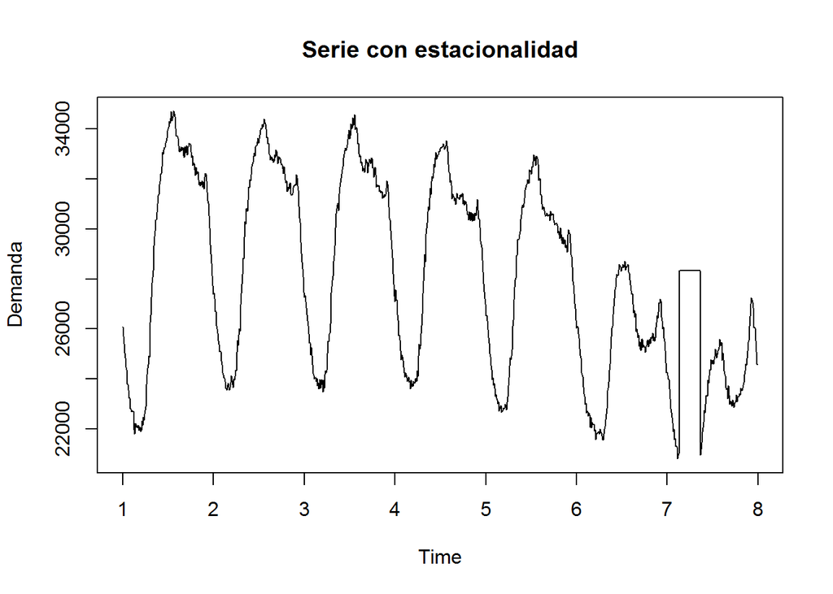

```r
plot(ts,  main = "Serie con estacionalidad", ylab = "Demanda")
```

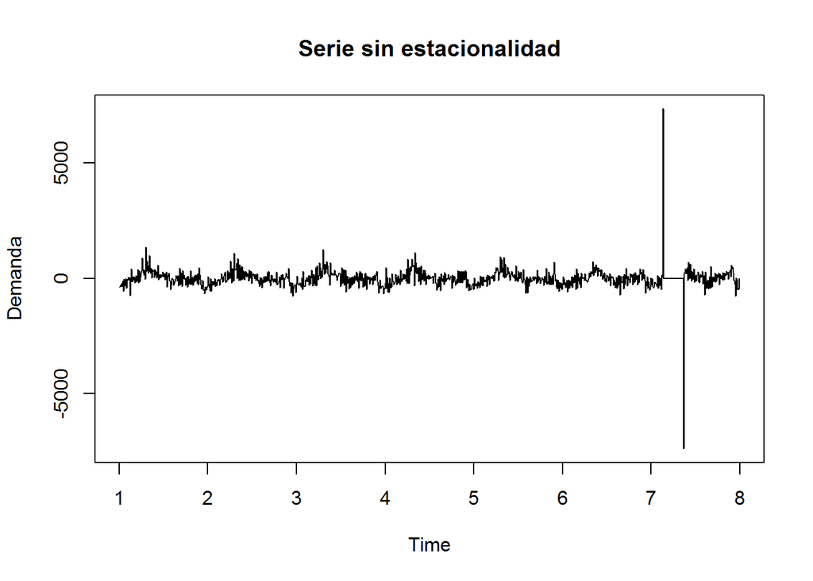

```r
tsstationary <- diff(ts, differences = 1)
plot(tsstationary, main = "Serie sin estacionalidad", ylab = "Demanda")
```

Como podemos ver ahora se ha eliminado la componente de estacionalidad de la serie. Aunque la serie parece tener ruido, que analizaremos más adelante, se parece bastante a una serie estacionaria, ya que parece ser constante en media y varianza. Aún así, lo comprobaremos visualizando la gráfica de la función de autocorrelación.

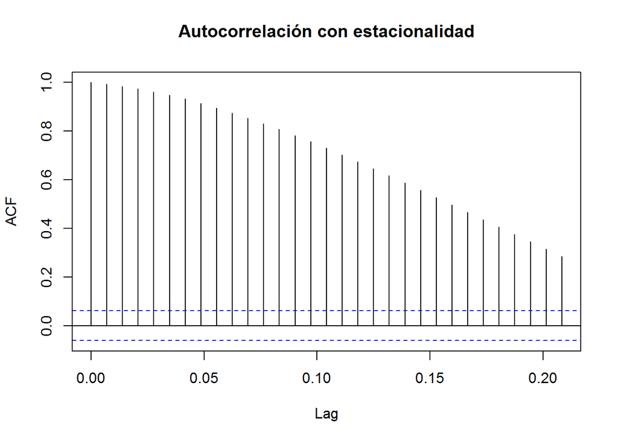

```r
acf(ts, main = "Autocorrelación con estacionalidad")
```

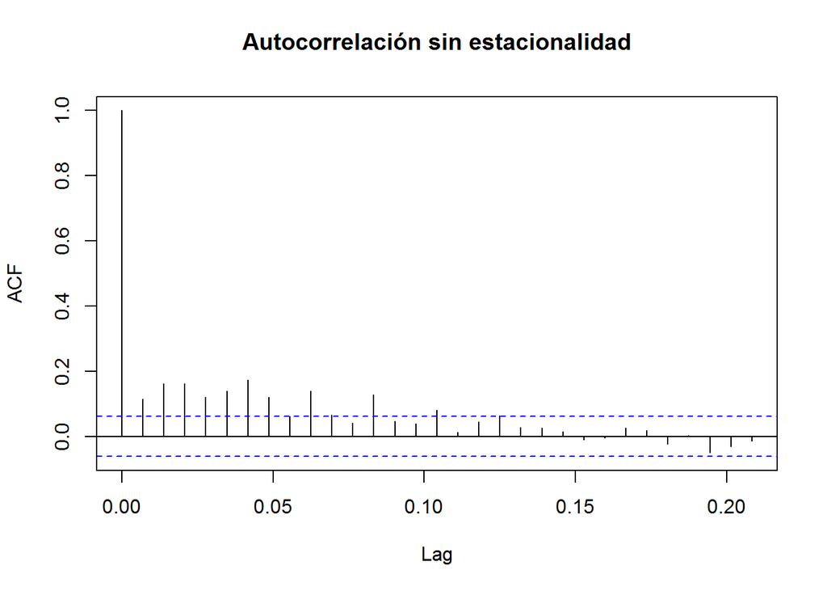

```r
acf(tsstationary, main = "Autocorrelación sin estacionalidad")
```

Podemos apreciar que la serie ya es estacionaria una vez se ha eliminado la componente estacional. Para asegurarnos se aplican las pruebas de estacionalidad como la prueba de [Dickey-Fuller Aumentado](https://en.wikipedia.org/wiki/Augmented_Dickey%E2%80%93Fuller_test) *(Augmented Dickey-Fuller Test (ADF), en inglés)* y la prueba de [Phillips–Perron](https://en.wikipedia.org/wiki/Phillips%E2%80%93Perron_test) (PP), una modificación de la prueba de Dickey-Fuller.

En estas pruebas, se considera que en la hipótesis nula ($H_{0}$) se observan raíces unitarias en la serie, por tanto, no es estacionaria. Al contrario, la serie es estacionaria ($H_{1}$). Con un *p-value* inferior a 0.05 (significancia $\alpha$), la hipótesis nula ($H_{0}$) se rechaza, confirmando que la serie es estacionaria.

El motivo de basarse en la observación de las raíces unitarias es porqué una raíz unitaria, es una tendencia estocástica de la serie temporal. Algunas veces se le llama *“paseo aleatorio con deriva”*. Y, por tanto, si la serie temporal tiene raíces unitarias, ésta presenta un patrón sistemático que es impredecible. Entonces, la serie temporal es estacionaria si un cambio en el tiempo no cambia la forma de la distribución, y las raíces unitarias son una causa de no estacionalidad.

Primero se aplica la prueba de Dickey-Fuller Aumentado:

```r
adf.test(tsstationary)
```

```
##
##  Augmented Dickey-Fuller Test
##
## data:  tsstationary
## Dickey-Fuller = -6.8215, Lag order = 10, p-value = 0.01
## alternative hypothesis: stationary
```

El valor del *p-value* de 0.01 nos indica que rechazamos la hipótesis nula ($H_{0}$), la serie es estacionaria. Y a continuación se aplica la prueba de Phillips–Perron:

```r
pp.test(tsstationary)
```

```
##
##  Phillips-Perron Unit Root Test
##
## data:  tsstationary
## Dickey-Fuller Z(alpha) = -1191.1, Truncation lag parameter = 7, p-value
## = 0.01
## alternative hypothesis: stationary
```

El valor del *p-value* de 0.01 nos indica que también rechazamos la hipótesis nula ($H_{0}$), la serie es estacionaria. Se ha eliminado correctamente la estacionalidad y ya se puede ajustar el modelo.

## Ajuste del modelo

Después de eliminar la estacionalidad y hacer que los datos sean estacionarios, se dividen los datos en un conjunto de entrenamiento y en un conjunto de prueba.

```r
trainset <- subset(tsstationary,
                   end = length(tsstationary) - (24 * 60 / 10))
testset <- subset(tsstationary,
                  start = length(tsstationary) - (24 * 60 / 10) + 1)
```

Una vez que tenemos los datos listos y han satisfecho todas las suposiciones del modelo ARIMA, para determinar el orden del modelo que se ajustará a los datos, necesitamos tres variables: $p$, $d$ y $q$ que son los enteros positivos que se refieren al orden de las partes medias autorregresivas, integradas y móviles del modelo, que se describen en el capítulo anterior.

Para identificar que valores de $p$, $d$ y $q$ serán apropiados, se usa la función *auto.arima()*. La función calcula automáticamente cuál es la mejor combinación de órdenes para el modelo. Para ello, utiliza una combinación de pruebas de raíz unitaria, minimización de los valores AIC y [MLE](https://en.wikipedia.org/wiki/Maximum_likelihood_estimation) para obtener el mejor modelo. Básicamente, los valores $p$, $d$ y $q$ son elegidos minimizando el AIC. La función utiliza el algoritmo Hyndman & Khandakar (2008), que usa una búsqueda por pasos para recorrer el espacio del modelo para seleccionar el mejor modelo con el AIC más pequeño.

```r
fitARIMA <- auto.arima(trainset, trace = TRUE)
```

```
##
##  Fitting models using approximations to speed things up...
##
##  ARIMA(2,0,2)(1,1,1)[144] with drift         : Inf
##  ARIMA(0,0,0)(0,1,0)[144] with drift         : 8444.229
##  ARIMA(1,0,0)(1,1,0)[144] with drift         : Inf
##  ARIMA(0,0,1)(0,1,1)[144] with drift         : Inf
##  ARIMA(0,0,0)(0,1,0)[144]                    : 8442.454
##  ARIMA(0,0,0)(1,1,0)[144] with drift         : Inf
##  ARIMA(0,0,0)(0,1,1)[144] with drift         : Inf
##  ARIMA(0,0,0)(1,1,1)[144] with drift         : Inf
##  ARIMA(1,0,0)(0,1,0)[144] with drift         : 8336.283
##  ARIMA(1,0,0)(0,1,1)[144] with drift         : Inf
##  ARIMA(1,0,0)(1,1,1)[144] with drift         : Inf
##  ARIMA(2,0,0)(0,1,0)[144] with drift         : 8321.729
##  ARIMA(2,0,0)(1,1,0)[144] with drift         : Inf
##  ARIMA(2,0,0)(0,1,1)[144] with drift         : Inf
##  ARIMA(2,0,0)(1,1,1)[144] with drift         : Inf
##  ARIMA(3,0,0)(0,1,0)[144] with drift         : 8324.007
##  ARIMA(2,0,1)(0,1,0)[144] with drift         : 8322.7
##  ARIMA(1,0,1)(0,1,0)[144] with drift         : 8324.375
##  ARIMA(3,0,1)(0,1,0)[144] with drift         : 8325.721
##  ARIMA(2,0,0)(0,1,0)[144]                    : 8320.609
##  ARIMA(2,0,0)(1,1,0)[144]                    : Inf
##  ARIMA(2,0,0)(0,1,1)[144]                    : Inf
##  ARIMA(2,0,0)(1,1,1)[144]                    : Inf
##  ARIMA(1,0,0)(0,1,0)[144]                    : 8334.894
##  ARIMA(3,0,0)(0,1,0)[144]                    : 8322.812
##  ARIMA(2,0,1)(0,1,0)[144]                    : 8321.518
##  ARIMA(1,0,1)(0,1,0)[144]                    : 8323.262
##  ARIMA(3,0,1)(0,1,0)[144]                    : Inf
##
##  Now re-fitting the best model(s) without approximations...
##
##  ARIMA(2,0,0)(0,1,0)[144]                    : 9925.185
##
##  Best model: ARIMA(2,0,0)(0,1,0)[144]
```

```r
fitARIMA
```

```
## Series: trainset
## ARIMA(2,0,0)(0,1,0)[144]
##
## Coefficients:
##           ar1      ar2
##       -0.4298  -0.1501
## s.e.   0.0370   0.0370
##
## sigma^2 estimated as 57549:  log likelihood=-4959.58
## AIC=9925.15   AICc=9925.18   BIC=9938.88
```

En este caso la función sugiere que el mejor modelo que representa a la serie sería un ARIMA(2,0,0)(0,1,0) sin tendencia, y que arroja un AIC de 9925.15. Lo validaremos con la prueba *Ljung-Box* (una versión simplificada de la prueba de Box y Pierce) que evalúa si los residuos de la serie son ruido blanco (proceso estocástico estacionario).

La prueba de *Ljung-Box* es una prueba para comprobar si una serie de observaciones, en un período de tiempo específico, son aleatorias o independientes en todos los retardos hasta el retardo especificado. En lugar de probar la aleatoriedad en cada retardo distinto, se prueba la aleatoriedad *“general”* basada en un número de retardos y, por lo tanto, también es una prueba de comparación.

La prueba se aplica a los residuos de un modelo ARIMA ajustado y no a la serie original, y en tales aplicaciones, la hipótesis que se prueba es que los residuos del modelo no tengan autocorrelación. Si los retardos no son independientes, un retardo puede estar relacionado con otros retardos de $k$ unidades de tiempo, por lo que la autocorrelación puede reducir la exactitud del modelo predictivo y conducir a una interpretación errónea de los datos. La hipótesis nula ($H_{0}$) indicará que los datos no son diferentes del ruido blanco ($H_{0}$: los residuos se distribuyen aleatoriamente).

A continuación, se aplica la prueba de *Ljung-Box* sobre el modelo ARIMA(2,0,0)(0,1,0), si el modelo rechaza la hipótesis nula $H_{0}$, debemos considerar el modelo como problemático.

```r
Box.test(fitARIMA$residuals, type = "Ljung-Box")
```

```
##
##  Box-Ljung test
##
## data:  fitARIMA$residuals
## X-squared = 0.023686, df = 1, p-value = 0.8777
```

En este caso, el valor de p (*p-value = 0.8777*) está lejos de ser significativo (inferior a 0.05). Por tanto, no podemos rechazar la hipótesis nula ($H_{0}$) de que los residuos se distribuyen aleatoriamente y se concluye que el modelo, como se especifica, se ha ajustado correctamente.

## Predicción

Los parámetros del modelo ARIMA se pueden usar como un modelo predictivo para hacer pronósticos de valores futuros de las series temporales, una vez que se selecciona el modelo más adecuado para los datos de la serie temporal. Se usa la función *forecast()* para la predicción de la serie temporal.

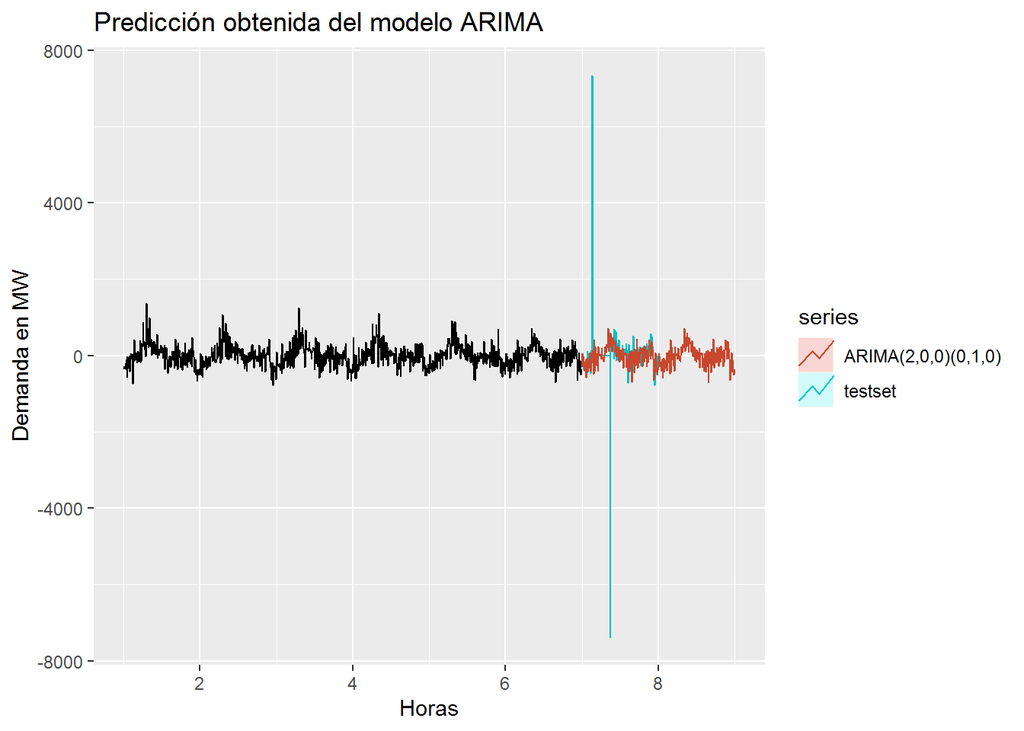

```r
forecastARIMA <- forecast(fitARIMA)
autoplot(trainset, xlab = "Horas", ylab = "Demanda en MW") +
  autolayer(testset) +
  autolayer(forecastARIMA, series = "ARIMA(2,0,0)(0,1,0)", PI = FALSE) +
  ggtitle("Predicción obtenida del modelo ARIMA")
```

```r
accuracy(forecastARIMA, tsstationary)
```

```
##                     ME     RMSE      MAE MPE MAPE      MASE        ACF1
## Training set -6.315023 218.6623 158.7233 NaN  Inf 0.7511491 0.005229768
## Test set     16.710446 933.6306 317.8420 NaN  Inf 1.5041692 0.022191664
##              Theil's U
## Training set        NA
## Test set           NaN
```

Finalmente, se guarda el resultado de la predicción en un fichero Excel. Para ello, necesitaremos el paquete [openxlsx](https://www.rdocumentation.org/packages/openxlsx/versions/4.2.3).

```r
library(openxlsx)

resultado <- createWorkbook()
addWorksheet(resultado, "resultado")
writeData(resultado, "resultado", forecastARIMA, rowNames = TRUE)
saveWorkbook(resultado, "resultado.xlsx", overwrite = TRUE)
```

Box, G.E.P. & Jenkins, G.M. (1976). *Time series analysis: Forecasting and control*. John Wiley & Sons.

Hyndman, R.J. & Khandakar, Y. (2008). Automatic time series forecasting: The forecast package for r. *Journal of Statistical Software*, **27**.